# Práctica 5

## David Montero Loaiza

### Problema 1

Realiza las siguientes tareas:

#### i) Simula 50 tiradas de un dado.

```r
n = 6

# 50 TIRADAS DE UN DADO
tir50 = sample(6,50,replace = TRUE)
print(tir50)
```

```
##  [1] 2 1 2 5 4 4 2 5 5 1 3 6 1 6 2 4 1 3 1 6 6 6 4 4 5 2 4 1 2 4 3 3 3 6 5
## [36] 3 5 5 1 1 5 3 2 5 5 4 6 3 3 2
```

#### ii) Considera la variable aleatoria, X, definida como el número que sale al tirar el dado. ¿Cuánto valen $\bar{X}$, $S^2$, $E(\bar{X})$, $Var(\bar{X})$, $E(X)$ y $Var(X)$?

```r
# MEDIA MUESTRAL
X = mean(tir50)
paste("Media muestral:",X)
```

```
## [1] "Media muestral: 3.5"
```

```r
# VARIANZA MUESTRAL
S2 = var(tir50)
paste("Varianza muestral:",S2)
```

```
## [1] "Varianza muestral: 2.8265306122449"
```

```r
# VALOR ESPERADO DE LA VARIABLE ALEATORIA
E = (n + 1)/2
paste("Valor esperado de la variable aleatoria:",E)
```

```
## [1] "Valor esperado de la variable aleatoria: 3.5"
```

```r
# VARIANZA DE LA VARIABLE ALEATORIA
V = (n^2 - 1)/12
paste("Varianza de la variable aleatoria:",V)
```

```
## [1] "Varianza de la variable aleatoria: 2.91666666666667"
```

```r
# VALOR ESPERADO DE LA MEDIA MUESTRAL
Ex = E
paste("Valor esperado de la media muestral:",Ex)
```

```
## [1] "Valor esperado de la media muestral: 3.5"
```

```r
# VARIANZA DE LA MEDIA MUESTRAL
Vx = V/n
paste("Varianza de la media muestral:",Vx)
```

```
## [1] "Varianza de la media muestral: 0.486111111111111"
```

### Problema 2

Realiza las siguientes tareas:

#### i) Simula 50 tiradas de dos dados.

```r
# 50 TIRADAS DE DOS DADOS
tir50_d1 = sample(6,50,replace = TRUE)
tir50_d2 = sample(6,50,replace = TRUE)
tir50_2dados = tir50_d1 + tir50_d2
print(tir50_2dados)
```

```
##  [1]  7  7  5 10  3  9 11  7 10  5  5  7  7  8  5  8  9  4  8 11  7  7 11
## [24]  7  5  5  8  9 11 10  7  6  9  7  4 10  4  6  9  4 11  9 11  3  3  9
## [47]  6  9  9  8
```

#### ii) Considera la variable aleatoria, X, definida como la suma de los números que salen al tirar dos dados. ¿Cuánto valen $\bar{X}$, $S^2$, $E(\bar{X})$, $Var(\bar{X})$, $E(X)$ y $Var(X)$?

```r
# MEDIA MUESTRAL
X = mean(tir50_2dados)
paste("Media muestral:",X)
```

```
## [1] "Media muestral: 7.4"
```

```r
# VARIANZA MUESTRAL
S2 = var(tir50_2dados)
paste("Varianza muestral:",S2)
```

```
## [1] "Varianza muestral: 5.63265306122449"
```

```r
# VALOR ESPERADO DE LA VARIABLE ALEATORIA
E = X
paste("Valor esperado de la variable aleatoria:",E)
```

```
## [1] "Valor esperado de la variable aleatoria: 7.4"
```

```r
# VARIANZA DE LA VARIABLE ALEATORIA
V = S2
paste("Varianza de la variable aleatoria:",V)
```

```
## [1] "Varianza de la variable aleatoria: 5.63265306122449"
```

```r
# VALOR ESPERADO DE LA MEDIA MUESTRAL
Ex = E
paste("Valor esperado de la media muestral:",Ex)
```

```
## [1] "Valor esperado de la media muestral: 7.4"
```

```r
# VARIANZA DE LA MEDIA MUESTRAL
Vx = V/50
paste("Varianza de la media muestral:",Vx)
```

```
## [1] "Varianza de la media muestral: 0.11265306122449"
```

### Problema 3

Realiza las siguientes tareas:

#### i) Simula alturas de 50 personas de una población de altura media 176 y desviación típica 11 centímetros.

```r
# SIMULACION DE 50 ALTURAS
mu = 176
sigma = 11
alturas = rnorm(50,mu,sigma)
print(alturas)
```

```
##  [1] 177.2202 175.7678 175.3045 196.1810 176.4637 196.2219 190.1815
##  [8] 171.4560 181.2764 181.2892 171.5350 164.1021 177.1551 174.4639
## [15] 179.4923 153.8359 177.6596 182.8560 161.8179 172.7425 173.2267
## [22] 184.7501 187.8288 181.4205 164.0698 166.5745 175.6409 190.1404
## [29] 152.5997 181.8708 157.2019 167.6918 170.2912 188.9405 180.5594
## [36] 168.9133 150.7227 164.9564 179.4633 183.8053 180.5883 185.5161
## [43] 169.2278 176.7312 185.9571 161.7496 173.8819 156.7214 160.3377
## [50] 169.9761
```

#### ii) Considera la variable aleatoria, X, definida como la altura de una persona de la población descrita anteriormente. ¿Cuánto valen $\bar{X}$, $S^2$, $E(\bar{X})$, $Var(\bar{X})$, $E(X)$ y $Var(X)$?

```r
# MEDIA MUESTRAL
X = mean(alturas)
paste("Media muestral:",X)
```

```
## [1] "Media muestral: 174.567555011493"
```

```r
# VARIANZA MUESTRAL
S2 = var(alturas)
paste("Varianza muestral:",S2)
```

```
## [1] "Varianza muestral: 119.094893863466"
```

```r
# VALOR ESPERADO DE LA VARIABLE ALEATORIA
E = X
paste("Valor esperado de la variable aleatoria:",E)
```

```
## [1] "Valor esperado de la variable aleatoria: 174.567555011493"
```

```r
# VARIANZA DE LA VARIABLE ALEATORIA
V = S2
paste("Varianza de la variable aleatoria:",V)
```

```
## [1] "Varianza de la variable aleatoria: 119.094893863466"
```

```r
# VALOR ESPERADO DE LA MEDIA MUESTRAL
Ex = E
paste("Valor esperado de la media muestral:",Ex)
```

```
## [1] "Valor esperado de la media muestral: 174.567555011493"
```

```r
# VARIANZA DE LA MEDIA MUESTRAL
Vx = V/50
paste("Varianza de la media muestral:",Vx)
```

```
## [1] "Varianza de la media muestral: 2.38189787726931"
```

### Problema 4

Realiza las siguientes tareas:

#### i) Simula el número de goles marcados en 10 partidos siendo el promedio de goles por partido en la liga 2.8.

```r
# SIMULACION DEL NUMERO DE GOLES
lambda = 2.8
goles = rpois(10,lambda)
print(goles)
```

```
##  [1] 3 1 5 3 5 1 2 0 2 1
```

#### ii) Considera la variable aleatoria, X, definida como el número de goles en un partido de la liga anteriormente mencionada. ¿Cuánto valen $\bar{X}$, $S^2$, $E(\bar{X})$, $Var(\bar{X})$, $E(X)$ y $Var(X)$?

```r
# MEDIA MUESTRAL
X = mean(goles)
paste("Media muestral:",X)
```

```
## [1] "Media muestral: 2.3"
```

```r
# VARIANZA MUESTRAL
S2 = var(goles)
paste("Varianza muestral:",S2)
```

```
## [1] "Varianza muestral: 2.9"
```

```r
# VALOR ESPERADO DE LA VARIABLE ALEATORIA
E = lambda
paste("Valor esperado de la variable aleatoria:",E)
```

```
## [1] "Valor esperado de la variable aleatoria: 2.8"
```

```r
# VARIANZA DE LA VARIABLE ALEATORIA
V = lambda
paste("Varianza de la variable aleatoria:",V)
```

```
## [1] "Varianza de la variable aleatoria: 2.8"
```

```r
# VALOR ESPERADO DE LA MEDIA MUESTRAL
Ex = E
paste("Valor esperado de la media muestral:",Ex)
```

```
## [1] "Valor esperado de la media muestral: 2.8"
```

```r
# VARIANZA DE LA MEDIA MUESTRAL
Vx = V/10
paste("Varianza de la media muestral:",Vx)
```

```
## [1] "Varianza de la media muestral: 0.28"
```

### Problema 5

Simula las posiciones de 32 fichas colocadas al azar en un tablero de 8 por 8 casillas, teniendo en cuenta que solo puede haber una ficha por casilla.

```r
# SIMULAR LAS POSICIONES DE 32 FICHAS
x = c(rep(1,32),rep(0,32))
tablero = matrix(sample(x,8*8),8,8)
print(tablero)
```

```
##      [,1] [,2] [,3] [,4] [,5] [,6] [,7] [,8]
## [1,]    0    0    0    1    0    1    1    0
## [2,]    0    0    1    1    0    0    1    1
## [3,]    1    0    1    0    0    1    1    1
## [4,]    1    0    1    0    1    0    1    1
## [5,]    0    1    1    1    1    1    0    0
## [6,]    1    0    0    0    1    0    0    1
## [7,]    0    1    0    1    0    1    1    0
## [8,]    0    1    0    0    1    1    0    0
```

### Problema 6

Representa gráficamente cada una de las muestras simuladas y guarda las gráficas en archivo.

#### Simulación de 50 tiradas de un dado

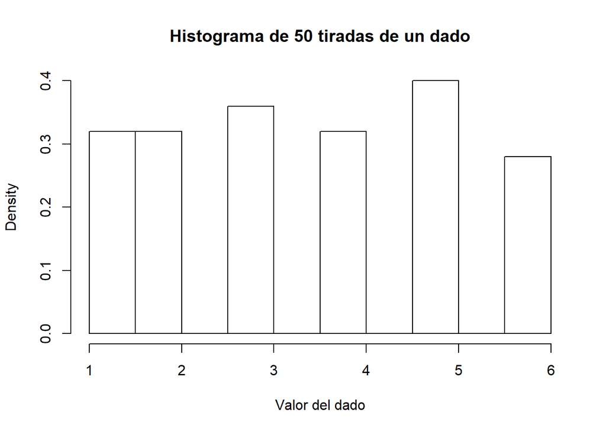

```r
hist(tir50,main = "Histograma de 50 tiradas de un dado",xlab = "Valor del dado",freq = FALSE,breaks = 10)
```

#### Simulación de 50 tiradas de dos dados

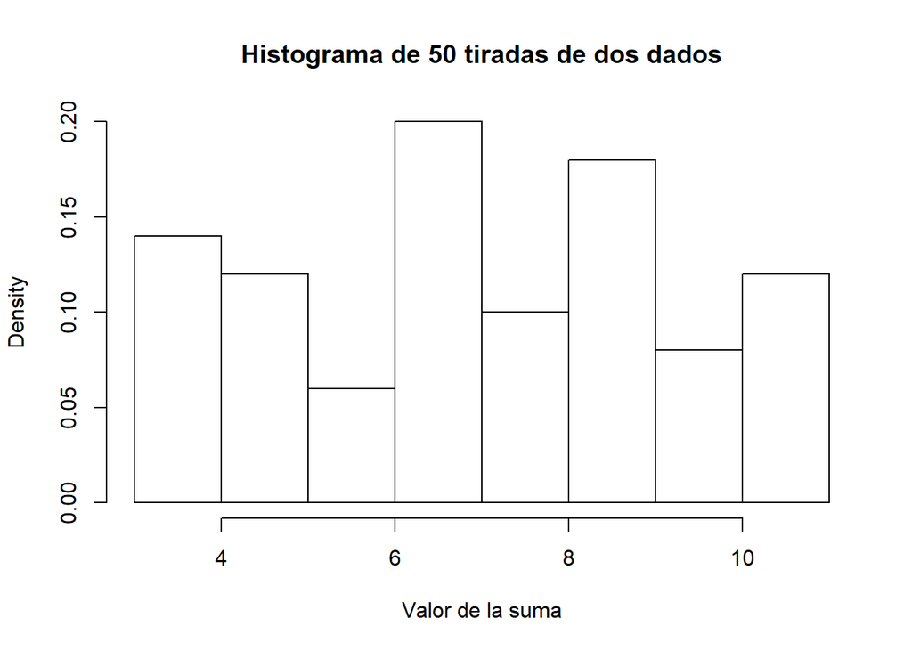

```r
hist(tir50_2dados,main = "Histograma de 50 tiradas de dos dados",xlab = "Valor de la suma",freq = FALSE,breaks = 10)
```

#### Simulación de 50 alturas

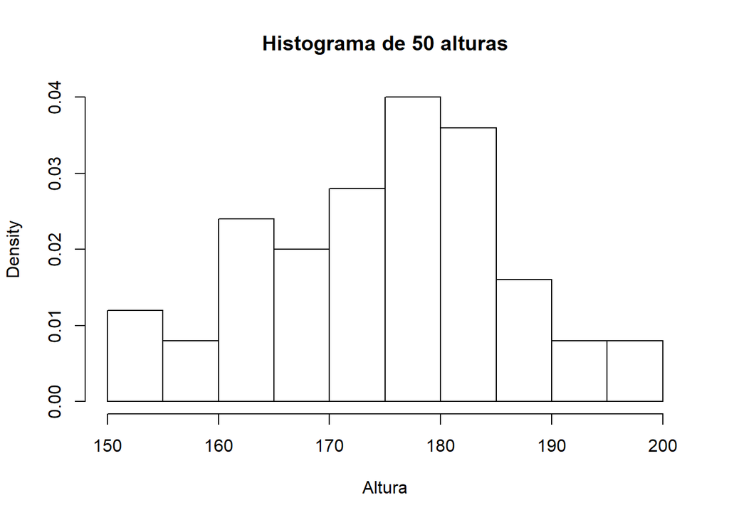

```r
hist(alturas,main = "Histograma de 50 alturas",xlab = "Altura",freq = FALSE,breaks = 10)
```

#### Simulación del número de goles en 10 partidos

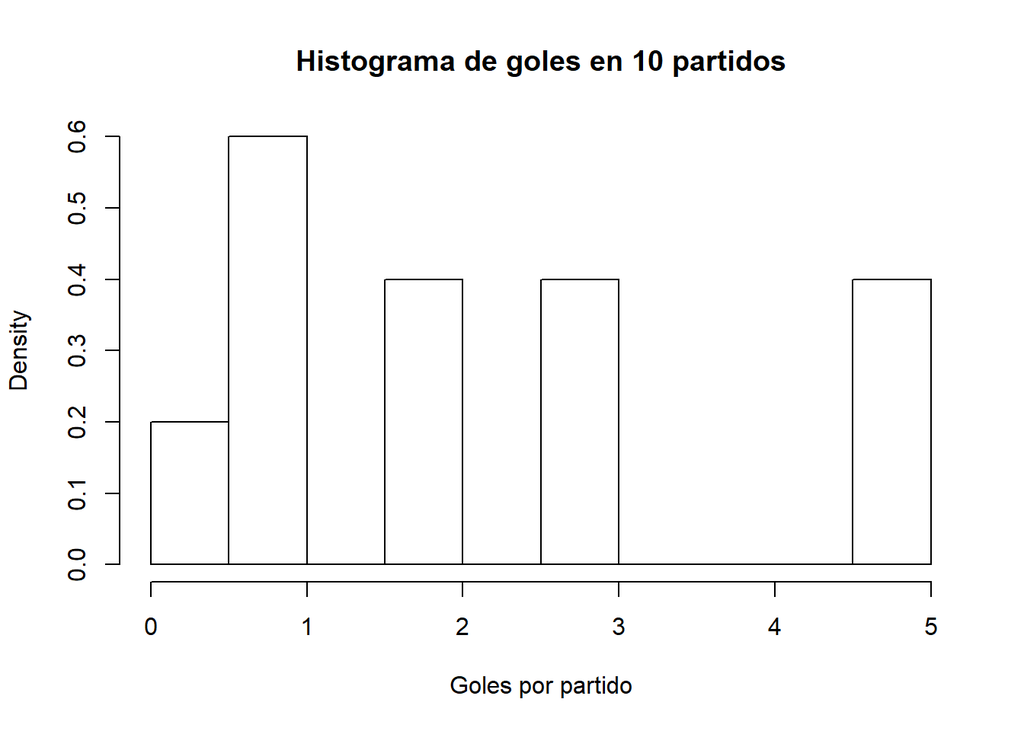

```r
hist(goles,main = "Histograma de goles en 10 partidos",xlab = "Goles por partido",freq = FALSE,breaks = 10)
```

#### Simulación de posiciones de 32 fichas en un tablero

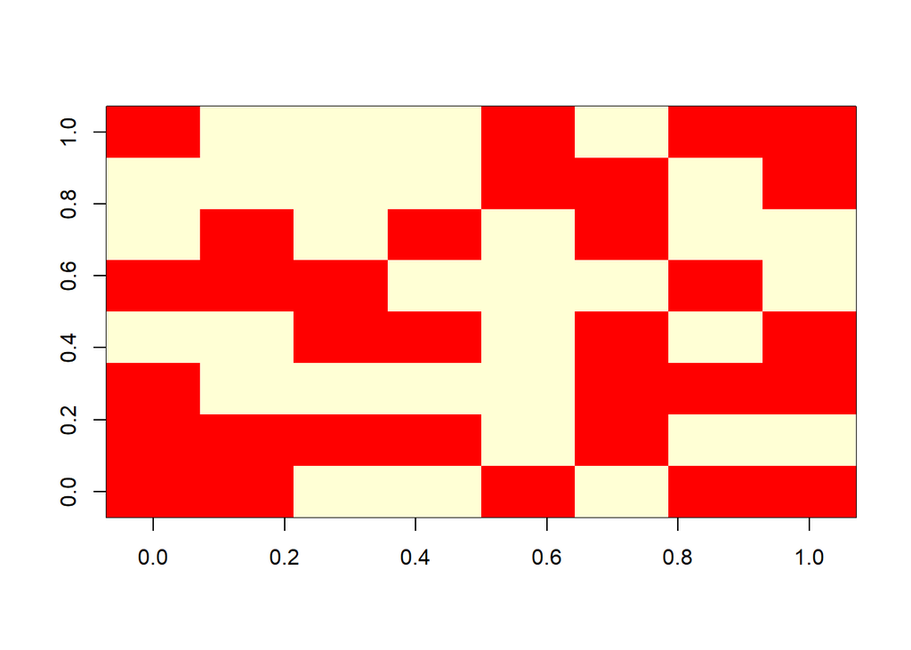

```r
image(tablero)
```